# Pop Gen Problem set 2

Mei Iwamoto

2024-10-29

1.a) calculate p^2 for each disease based off of the allele frequency for p.

```r
#cystic fibrosis
cfp <- ((9*2)+842)/(23369*2) #p denotes allele frequency
(cfp^2)*23369 #p^2 *number of individuals to get expected genotype freq
```

```
## [1] 7.912191
```

```r
#expected is 7.91, observed is 9
```

```r
#sickle cell anemia
scap <- ((2*2)+307)/(21360*2)
(scap^2)*21360
```

```
## [1] 1.132034
```

```r
#expected is 1.13, observed is 2
```

```r
#B-thalassemia
btp <- ((1*2)+158)/(21096*2)
(btp^2)*21096
```

```
## [1] 0.303375
```

```r
#expected is 0.30, observed is 1
```

The numbers for each disease is not completely consistent with Hardy Weinberg but is only off by a little. I would expect them to not be consistent with Hardy-Weinberg because these diseases could lead to lower fitness for affected individuals and selection would work against them.

2. Hemoglobin in Baltic cod

```r
hbn <- 418+749+2306 #total number of individuals
hbp <- ((2306*2)+749)/(hbn*2)
(hbp^2)*hbn
```

```
## [1] 2068.84
```

The dataset of hemoglobin alleles in Baltic cod is also not consistent/slightly off with Hardy-Weinberg predictions. This may be because hemoglobin alleles may confer an important fitness effect to the individual, leading to it being selected for and thus violating one of HWE’s assumptions.

3. Hemoglobin S

```r
ssn <- 366+123+12 #number of individuals
ssp <- ((12*2)+123)/(ssn*2)
(ssp^2)*ssn
```

```
## [1] 10.78293
```

Also not consistent with HWE but close - being a homozygous carrier for sickle cell anemia may lead to lowered fitness effects, thus being selected against.

4. canadian Daphnia pulex

```r
pgin <- 34+100
pgip <- 100/(pgin*2)
(pgip^2)*pgin
```

```
## [1] 18.65672
```

Not consistent with HWE as there are 0 individuals homozygous for PGI2. This might suggest that being homozygous for that allele is fatal?

2. One definition for inbreeding is an inability of selection to drive out harmful recessive alleles in a population. One predicted effect of inbreeding is an increase in homozygosity, thereby leading to a decrease in genetic diversity.
2. inbreeding coefficient F = (Ho - H)/Ho, where Ho = 2pq, freq. of heterozygous genotypes and H = freq. of heterozygous genotypes at the present time.

```r
#cystic fibrosis
cfq <- 1-cfp
cf2pq <- 2*cfp*cfq #Ho
cf <- 842/23369 #H
cfF <- (cf2pq-cf)/(cf2pq) #inbreeding coefficient F
```

Sickle Cell Anemia

```r
scaq <- 1-scap
sca2pq <- 2*scap*scaq
sca <- 307/21360
scaF <- (sca2pq-sca)/sca2pq
```

B-thalassemia

```r
btq <- 1-btp
bt2pq <- 2*btp*btq
bt <- 158/21096
btF <- (bt2pq-bt)/bt2pq
```

Baltic Cod

```r
hbq <- 1-hbp
hb2pq <- 2*hbp*hbq
hb <- 749/hbn
hbF <- (hb2pq-hb)/hb2pq
```

Hemoglobin S

```r
ssq <- 1-ssp
ss2pq <- 2*ssq*ssp
ss <- 123/ssn
ssF <- (ss2pq-ss)/ss2pq
```

Daphnia pulex

```r
pgiq <- 1-pgip
pgi2pq <- 2*pgip*pgiq
pgi <- 100/pgin
pgiF <- (pgi2pq-pgi)/pgi2pq
```

3. ABO Blood types among patients - calculate chi-squared, df, p-value. Df = 3 = 4 outcomes - 1.

blood type A

```r
ae <- 71953/173380 #expected freq of blood type a
aob <- 30/78 #observed freq of blood type a in patients
achi <- ((aob-ae)^2)/ae
pchisq(achi, 3, lower.tail=F)
```

```
## [1] 0.9999721
```

Blood type O

```r
oe <- 58776/173380
oob <- 36/78
ochi <- ((oob-oe)^2)/oe
pchisq(ochi, 3, lower.tail=F)
```

```
## [1] 0.9975534
```

Blood Type B

```r
be <- 30341/173380
bo <- 7/78
bchi <- ((bo-be)^2)/be
pchisq(bchi, 3, lower.tail=F)
```

```
## [1] 0.9977767
```

Blood Type AB

```r
abe <- 12310/173380
abo <- 5/78
abchi<- ((abo-abe)^2)/abe
pchisq(abchi, 3, lower.tail=F)
```

```
## [1] 0.9999954
```

4. Illustrate the process of genetic drift for five new spontaneous mutations, each with an initial frequency of p=1/2n, for each of the three population sizes (50, 100, 1000).

n=50

```r
n1 <- 50 #initial population size
1/(2*n1) #initial freq., = 0.01
```

```
## [1] 0.01
```

```r
a1 <- matrix(data = NA, nrow = 100, ncol = 100)
a2 <- matrix(data = NA, nrow = 100, ncol = 100)
a3 <- matrix(data = NA, nrow = 100, ncol = 100)
a4 <- matrix(data = NA, nrow = 100, ncol = 100)
a5 <- matrix(data = NA, nrow = 100, ncol = 100)

afreq <- matrix(data=NA, nrow=100, ncol=5)

sam <- matrix(data=NA, nrow=100, ncol=5)

for (m in 1:5) {
  sam[1:100, m] <- sample(c("a","A"), size = 100, replace=T, prob=c(0.01,0.99))
}
```

Run five simulations for the five spontaneous mutations.

```r
#first simulation
a1[1:100, 1] <- sam[,1]

for (i in 1:99) {
  a1[1:100, 1+i] <- sample(a1[1:100, i], size=100, replace=T)
  afreq[i,1] <- (length(a1[a1[1:100, i]=="a"])/100)
}

#second simulation
a2[1:100, 1] <- sam[,2]

for (i in 1:99) {
  a2[1:100, 1+i] <- sample(a2[1:100, i], size=100, replace=T)
  afreq[i,2] <- (length(a2[a2[1:100, i]=="a"])/100)
}

#second simulation
a2[1:100, 1] <- sam[,2]

for (i in 1:99) {
  a2[1:100, 1+i] <- sample(a2[1:100, i], size=100, replace=T)
  afreq[i,2] <- (length(a2[a2[1:100, i]=="a"])/100)
}


#third simulation
a3[1:100, 1] <- sam[,3]

for (i in 1:99) {
  a3[1:100, 1+i] <- sample(a3[1:100, i], size=100, replace=T)
  afreq[i,3] <- (length(a3[a3[1:100, i]=="a"])/100)
}


#fourth simulation
a4[1:100, 1] <- sam[,4]

for (i in 1:99) {
  a4[1:100, 1+i] <- sample(a4[1:100, i], size=100, replace=T)
  afreq[i,4] <- (length(a4[a4[1:100, i]=="a"])/100)
}


#fifth simulation
a5[1:100, 1] <- sam[,5]

for (i in 1:99) {
  a5[1:100, 1+i] <- sample(a5[1:100, i], size=100, replace=T)
  afreq[i,5] <- (length(a5[a5[1:100, i]=="a"])/100)
}
```

Plot all five simulations with popsize=50 on the same graph.

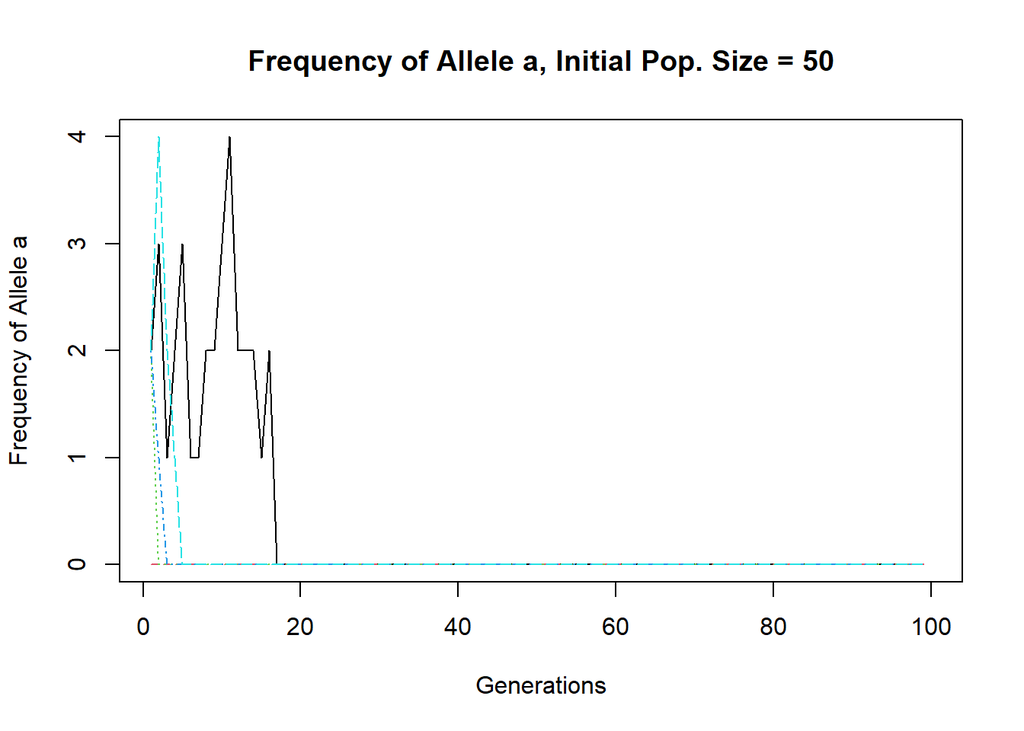

```r
#use matplot for plotting matrices
matplot(afreq, type = 'l', xlab = 'Generations', ylab='Frequency of Allele a', main='Frequency of Allele a, Initial Pop. Size = 50')
```

n=100

```r
n2 <- 100
1/(2*n2) #initial freq., 0.005
```

```
## [1] 0.005
```

```r
b1 <- matrix(data = NA, nrow = 200, ncol = 100)
b2 <- matrix(data = NA, nrow = 200, ncol = 100)
b3 <- matrix(data = NA, nrow = 200, ncol = 100)
b4 <- matrix(data = NA, nrow = 200, ncol = 100)
b5 <- matrix(data = NA, nrow = 200, ncol = 100)

bfreq <- matrix(data=NA, nrow=100, ncol=5)

samb <- matrix(data=NA, nrow=200, ncol=5)

for (m in 1:5) {
  samb[1:200, m] <- sample(c("a","A"), size = 200, replace=T, prob=c(0.005,0.995))

}
```

Run simulations for the five mutations

```r
#1st simulation
b1[1:200, 1] <- samb[,1]

for (i in 1:99) {
  b1[1:200, 1+i] <- sample(b1[1:200, i], size=200, replace=T)
  bfreq[i,1] <- (length(b1[b1[1:200, i]=="a"])/200)
}


#2nd simulation
b2[1:200, 1] <- samb[,2]

for (i in 1:99) {
  b2[1:200, 1+i] <- sample(b2[1:200, i], size=200, replace=T)
  bfreq[i,2] <- (length(b2[b2[1:200, i]=="a"])/200)
}

#3rd simulation
b3[1:200, 1] <- samb[,3]

for (i in 1:99) {
  b3[1:200, 1+i] <- sample(b3[1:200, i], size=200, replace=T)
  bfreq[i,3] <- (length(b3[b3[1:200, i]=="a"])/200)
}

#4th simulation
b4[1:200, 1] <- samb[,4]

for (i in 1:99) {
  b4[1:200, 1+i] <- sample(b4[1:200, i], size=200, replace=T)
  bfreq[i,4] <- (length(b4[b4[1:200, i]=="a"])/200)
}

#5th simulation
b5[1:200, 1] <- samb[,5]

for (i in 1:99) {
  b5[1:200, 1+i] <- sample(b5[1:200, i], size=200, replace=T)
  bfreq[i,5] <- (length(b5[b5[1:200, i]=="a"])/200)
}
```

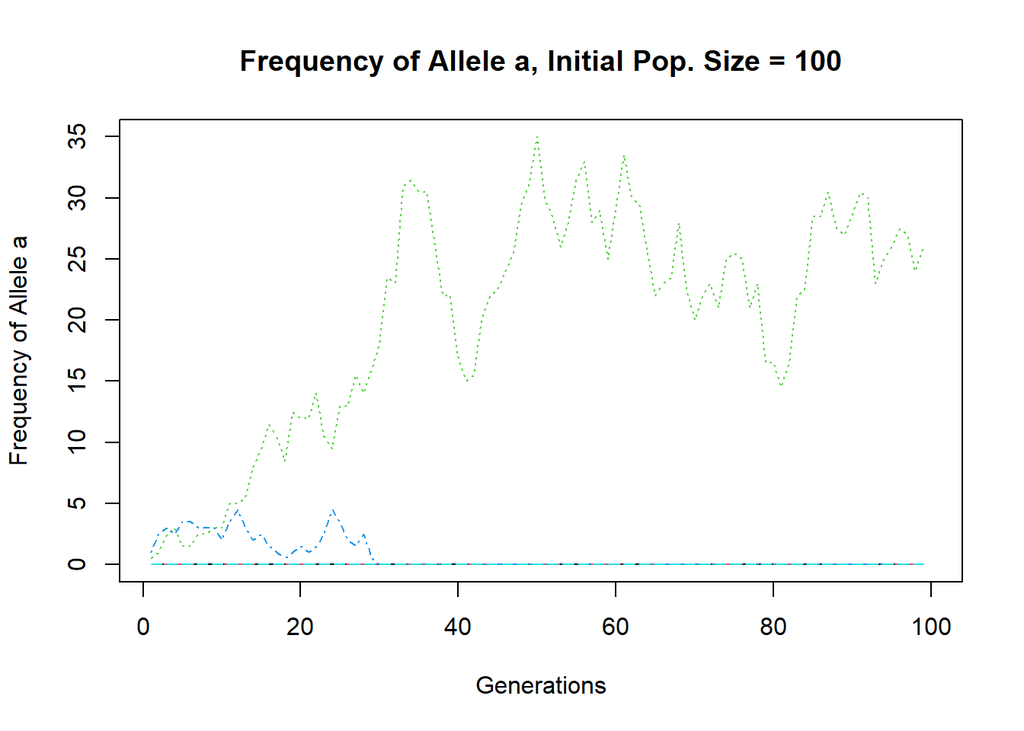

```r
#Use matplot to plot for initial population size of 100
matplot(bfreq, type = 'l', xlab = 'Generations', ylab='Frequency of Allele a', main='Frequency of Allele a, Initial Pop. Size = 100')
```

n=1000

```r
n3 <- 1000
1/(2*n3) # 0.0005, initial freq
```

```
## [1] 5e-04
```

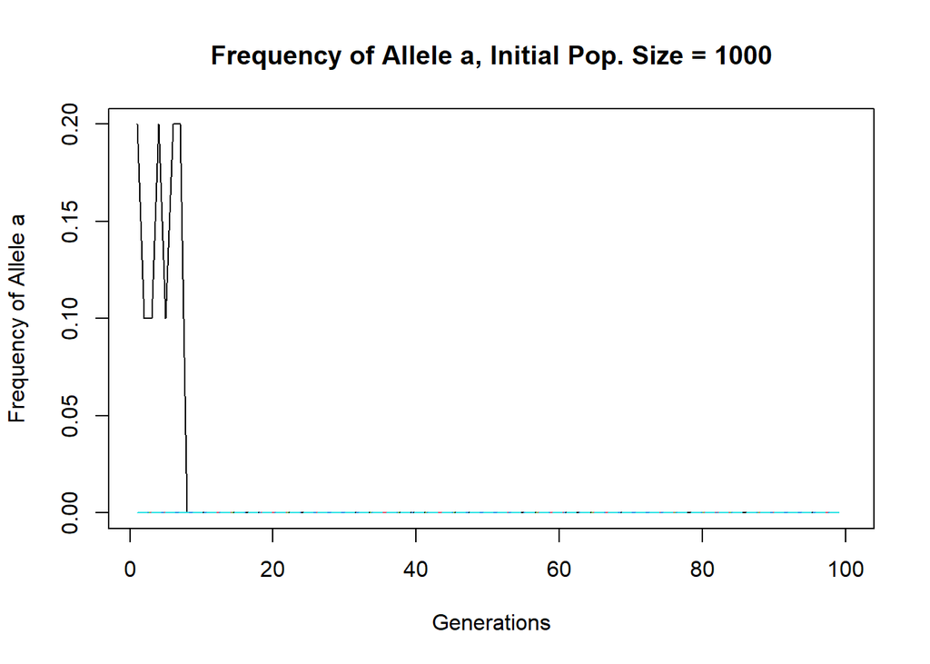

```r
c1 <- matrix(data = NA, nrow = 1000, ncol = 100)
c2 <- matrix(data = NA, nrow = 1000, ncol = 100)
c3 <- matrix(data = NA, nrow = 1000, ncol = 100)
c4 <- matrix(data = NA, nrow = 1000, ncol = 100)
c5 <- matrix(data = NA, nrow = 1000, ncol = 100)

cfreq <- matrix(data=NA, nrow=100, ncol=5)

samc <- matrix(data=NA, nrow=1000, ncol=5)

for (m in 1:5) {
  samc[1:1000, m] <- sample(c("a","A"), size = 1000, replace=T, prob=c(0.0005,0.9995))
}

#1st simulation
c1[1:1000, 1] <- samc[,1]

for (i in 1:99) {
  c1[1:1000, 1+i] <- sample(c1[1:1000, i], size=1000, replace=T)
  cfreq[i,1] <- (length(c1[c1[1:1000, i]=="a"])/1000)
}

#2nd simulation
c2[1:1000, 1] <- samc[,2]

for (i in 1:99) {
  c2[1:1000, 1+i] <- sample(c2[1:1000, i], size=1000, replace=T)
  cfreq[i,2] <- (length(c2[c2[1:1000, i]=="a"])/1000)
}

#3rd simulation
c3[1:1000, 1] <- samc[,3]

for (i in 1:99) {
  c3[1:1000, 1+i] <- sample(c3[1:1000, i], size=1000, replace=T)
  cfreq[i,3] <- (length(c3[c3[1:1000, i]=="a"])/1000)
}

#4th simulation
c4[1:1000, 1] <- samc[,4]

for (i in 1:99) {
  c4[1:1000, 1+i] <- sample(c4[1:1000, i], size=1000, replace=T)
  cfreq[i,4] <- (length(c4[c4[1:1000, i]=="a"])/1000)
}

#5th simulation
c5[1:1000, 1] <- samc[,5]

for (i in 1:99) {
  c5[1:1000, 1+i] <- sample(c5[1:1000, i], size=1000, replace=T)
  cfreq[i,5] <- (length(c5[c5[1:1000, i]=="a"])/1000)
}

#Use matplot to plot for initial population size of 1000
matplot(cfreq, type = 'l', xlab = 'Generations', ylab='Frequency of Allele a', main='Frequency of Allele a, Initial Pop. Size = 1000')
```

[output not shown]